# Homework 03

## Question 1: Build an explain-to-me skill

I tested it with this prompt:

> Use `$explain-to-me` to read and explain Question 2.

The response said that Question 2 asks me to create one fixed standardized design where the first two predictors are almost the same, and then compare OLS with two ridge penalties over 200 new pairs of responses. It separated the requested work into the design diagnostics, the simulation summaries, and the bias-variance interpretation. It pointed me to **A controlled experiment: stability under correlation** in the first ridge lecture. It suggested generating and standardizing the design once, outside the simulation loop, as the first step. It did not give any calculations or code.

## Question 2: Ridge regression with nearly collinear predictors

### a. Fixed design

```r
set.seed(43231)

n <- 100
p <- 4
repetitions <- 200
lambda_values <- c(0, 0.02, 0.2)

L <- rnorm(n)
U1 <- rnorm(n)
U2 <- rnorm(n)

X <- cbind(
  x1 = L + 0.04 * U1,
  x2 = L + 0.04 * U2,
  x3 = rnorm(n),
  x4 = rnorm(n)
)

X <- sweep(X, 2, colMeans(X), "-")
x_scale <- sqrt(colMeans(X^2))
X <- sweep(X, 2, x_scale, "/")

singular_values <- svd(X, nu = 0, nv = 0)$d
design_numbers <- c(
  correlation = cor(X[, 1], X[, 2]),
  largest_singular_value = max(singular_values),
  smallest_singular_value = min(singular_values)
)

round(design_numbers, 4)
```

```
            correlation  largest_singular_value smallest_singular_value
                 0.9977                 14.1415                  0.4754
```

The correlation is 0.9977. The largest and smallest singular values are 14.141 and 0.475. The first two columns are therefore almost redundant.

The sum of their coefficients controls the shared direction in the two columns. There is a lot of information in that direction. The difference moves the two coefficients in opposite directions, and this barely changes the fitted values because the columns are so similar. That nearly flat direction is connected to the small singular value, so response noise can produce a large change in the estimated difference.

### b. Repeated responses

```r
beta <- c(1.5, 1.5, 1, 0)
mu <- drop(X %*% beta)

beta_hat <- array(
  NA_real_,
  dim = c(repetitions, p, length(lambda_values))
)
train_mse <- matrix(NA_real_, repetitions, length(lambda_values))
test_mse <- matrix(NA_real_, repetitions, length(lambda_values))

for (r in seq_len(repetitions)) {
  y <- mu + rnorm(n)
  y_star <- mu + rnorm(n)
  y_centered <- y - mean(y)

  for (j in seq_along(lambda_values)) {
    lambda <- lambda_values[j]
    beta_hat[r, , j] <- solve(
      crossprod(X) + n * lambda * diag(p),
      crossprod(X, y_centered)
    )

    fitted <- mean(y) + drop(X %*% beta_hat[r, , j])
    train_mse[r, j] <- mean((y - fitted)^2)
    test_mse[r, j] <- mean((y_star - fitted)^2)
  }
}

coefficient_summary <- do.call(
  rbind,
  lapply(seq_along(lambda_values), function(j) {
    b1 <- beta_hat[, 1, j]
    b2 <- beta_hat[, 2, j]
    data.frame(
      lambda = lambda_values[j],
      beta1 = sprintf("%.3f (%.3f)", mean(b1), sd(b1)),
      beta2 = sprintf("%.3f (%.3f)", mean(b2), sd(b2)),
      sum = sprintf("%.3f (%.3f)", mean(b1 + b2), sd(b1 + b2)),
      difference = sprintf("%.3f (%.3f)", mean(b1 - b2), sd(b1 - b2))
    )
  })
)

error_summary <- data.frame(
  lambda = lambda_values,
  average_training_MSE = colMeans(train_mse),
  average_test_MSE = colMeans(test_mse)
)

knitr::kable(
  coefficient_summary,
  caption = "Mean (standard deviation) over 200 repetitions"
)
```

Mean (standard deviation) over 200 repetitions

| lambda | beta1 | beta2 | sum | difference |
| --- | --- | --- | --- | --- |
| 0.00 | 1.496 (1.544) | 1.510 (1.549) | 3.005 (0.095) | -0.014 (3.091) |
| 0.02 | 1.487 (0.162) | 1.489 (0.166) | 2.976 (0.094) | -0.002 (0.314) |
| 0.20 | 1.368 (0.046) | 1.369 (0.047) | 2.737 (0.086) | -0.001 (0.034) |

```r
knitr::kable(
  error_summary,
  digits = 3,
  caption = "Average training and independent-test MSE"
)
```

Average training and independent-test MSE

| lambda | average_training_MSE | average_test_MSE |
| --- | --- | --- |
| 0.00 | 0.965 | 1.062 |
| 0.02 | 0.975 | 1.049 |
| 0.20 | 1.077 | 1.133 |

### c. Interpretation

OLS is nearly unbiased on average, but its first two coefficient estimates move a lot from one response sample to another. Their difference is especially unstable even though the sum stays close to 3.

At lambda 0.02, the individual standard deviations and the standard deviation of the difference fall sharply. The sum changes much less because ridge mostly removes movement in the weak direction. At lambda 0.2, the estimates are steadier again, but the sum is pulled farther below 3. This is visible as shrinkage bias, and the average test MSE starts increasing.

The fitted values do not change as much as the individual coefficients because a large positive change in the first coefficient can be offset by a large negative change in the second one. Ridge stops much of that exchange between the two coefficients without needing to move the fitted response by the same amount.

## Question 3: What does ridge regression shrink?

### a. Normal equation

Differentiating the objective gives

$$\nabla L_\lambda(\boldsymbol\beta)
=
-\frac{1}{n}\mathbf X^{\mathsf T}
(\widetilde{\mathbf y}-\mathbf X\boldsymbol\beta)
+
\lambda\boldsymbol\beta.$$

At the minimum the gradient is zero, so

$$\frac{1}{n}\mathbf X^{\mathsf T}\mathbf X
\widehat{\boldsymbol\beta}_\lambda
+
\lambda\widehat{\boldsymbol\beta}_\lambda
=
\frac{1}{n}\mathbf X^{\mathsf T}\widetilde{\mathbf y}.$$

Multiplying by n gives

$$\left(
\mathbf X^{\mathsf T}\mathbf X+n\lambda\mathbf I_p
\right)
\widehat{\boldsymbol\beta}_\lambda
=
\mathbf X^{\mathsf T}\widetilde{\mathbf y}.$$

For any nonzero vector a,

$$\mathbf a^{\mathsf T}
\left(
\mathbf X^{\mathsf T}\mathbf X+n\lambda\mathbf I_p
\right)
\mathbf a
=
\lVert\mathbf X\mathbf a\rVert_2^2
+
n\lambda\lVert\mathbf a\rVert_2^2.$$

When lambda is positive, the last term is positive. The whole matrix is positive definite and therefore invertible, even if the design itself is rank deficient or has more columns than rows.

### b. Singular directions

Using the compact SVD in the normal-equation solution gives

$$\widehat{\boldsymbol\beta}_\lambda
=
\mathbf V_r
\left(
\mathbf D_r^2+n\lambda\mathbf I_r
\right)^{-1}
\mathbf D_r\mathbf U_r^{\mathsf T}\widetilde{\mathbf y}.$$

Multiplying by X produces

$$\mathbf X\widehat{\boldsymbol\beta}_\lambda
=
\sum_{j=1}^r
\frac{d_j^2}{d_j^2+n\lambda}
\mathbf u_j\mathbf u_j^{\mathsf T}\widetilde{\mathbf y}.$$

This shows that the fitted component in direction u-j is multiplied by the requested shrinkage factor. Here, n times lambda equals 1, so

$$\rho_1
=
\frac{100}{101}
\approx 0.9901,
\qquad
\rho_2
=
\frac{4}{5}
=0.8000,
\qquad
\rho_3
=
\frac{0.04}{1.04}
\approx0.0385.$$

Including the unpenalized intercept,

$$\operatorname{df}_{\mathrm{eff}}(0.01)
=
1+0.9901+0.8000+0.0385
\approx2.8286.$$

### c. Strongest shrinkage

The third direction is shrunk the most. Its singular value is only 0.2, so the data contain little information in this direction and noise can cause a relatively large OLS change. Shrinking it reduces that part of prediction variance.

The cost would be large bias if the true mean response really had a large component in this same weak direction. Ridge would keep only about 3.85 percent of the least-squares fitted component there.

## Question 4: Ridge regression and optimization

### a. Condition numbers

Without the penalty,

$$\kappa(\mathbf A_0)
=
\frac{9}{0.01}
=900.$$

With lambda 0.09, the eigenvalues become 9.09 and 0.10, giving

$$\kappa(\mathbf A_\lambda)
=
\frac{9.09}{0.10}
=90.9.$$

The contours are still longer in one direction, but much less extreme. Ridge adds curvature to the nearly flat direction, so the objective is easier to optimize numerically.

### b. Gradient descent

For a quadratic objective,

$$\nabla L_\lambda(\boldsymbol\beta^{(k)})
=
\mathbf A_\lambda
\left(
\boldsymbol\beta^{(k)}-\widehat{\boldsymbol\beta}_\lambda
\right)
=
\mathbf A_\lambda\mathbf e^{(k)}.$$

Subtracting the minimizer from the update gives

$$\mathbf e^{(k+1)}
=
\left(
\mathbf I_p-\eta\mathbf A_\lambda
\right)
\mathbf e^{(k)}.$$

In a direction whose original eigenvalue is a, the ridge eigenvalue is a plus lambda, so its error multiplier is

$$1-\eta(a+\lambda).$$

All directions contract when

$$0<\eta<\frac{2}{M}
=
\frac{2}{9.09}
\approx0.2200.$$

For eta equal to 1 divided by M, the factor in the high-curvature direction is

$$1-\frac{9.09}{9.09}=0,$$

while the low-curvature factor is

$$1-\frac{0.10}{9.09}
\approx0.9890.$$

The first direction converges immediately, but the second one changes slowly. For eta equal to 2.1 divided by M, the factor in the largest-eigenvalue direction is

$$1-\frac{2.1(9.09)}{9.09}=-1.1.$$

Its magnitude is bigger than one. With the assumed nonzero starting error in that direction, the signs alternate and the error grows, so gradient descent does not converge.

### c. Statistical tuning is different

Lambda changes the estimator, not just the speed of the algorithm. Increasing it can improve the condition number, but it also increases shrinkage bias. Step size should be chosen so the optimizer accurately solves the objective. Lambda should instead be chosen using prediction information such as cross-validation or GCV.

## Question 5: Selecting the ridge penalty

### Setup

```r
realestate <- read.csv("data/realestate.csv")
split_info <- read.csv("data/realestate-split-folds.csv")

stopifnot(
  nrow(realestate) == 414,
  nrow(split_info) == 414,
  anyDuplicated(realestate$row_id) == 0,
  anyDuplicated(split_info$row_id) == 0
)

row_order <- match(split_info$row_id, realestate$row_id)
stopifnot(!anyNA(row_order))

course_data <- cbind(
  split_info,
  realestate[
    row_order,
    setdiff(names(realestate), "row_id"),
    drop = FALSE
  ]
)

predictor_names <- c(
  "date", "age", "distance",
  "stores", "latitude", "longitude"
)

stopifnot(
  all(vapply(course_data[predictor_names], is.numeric, logical(1))),
  !anyNA(course_data[c(predictor_names, "price", "split")]),
  !anyNA(course_data$cv_fold[course_data$split == "train"])
)

training_rows <- course_data$split == "train"
test_rows <- course_data$split == "test"

X_train_raw <- as.matrix(course_data[training_rows, predictor_names])
y_train <- course_data$price[training_rows]
X_test_raw <- as.matrix(course_data[test_rows, predictor_names])
fold_id <- course_data$cv_fold[training_rows]

stopifnot(
  nrow(X_train_raw) == 332,
  nrow(X_test_raw) == 82,
  setequal(fold_id, 1:10)
)

fit_ridge <- function(X_raw, y, lambda, X_new = NULL) {
  n_fit <- nrow(X_raw)
  p_fit <- ncol(X_raw)

  x_mean <- colMeans(X_raw)
  X_centered <- sweep(X_raw, 2, x_mean, "-")
  x_scale <- sqrt(colMeans(X_centered^2))
  if (any(x_scale == 0)) stop("A predictor has zero scale.")
  X_scaled <- sweep(X_centered, 2, x_scale, "/")

  y_mean <- mean(y)
  y_centered <- y - y_mean
  beta_scaled <- solve(
    crossprod(X_scaled) + n_fit * lambda * diag(p_fit),
    crossprod(X_scaled, y_centered)
  )

  fitted <- y_mean + drop(X_scaled %*% beta_scaled)
  new_fitted <- NULL
  if (!is.null(X_new)) {
    X_new_scaled <- sweep(X_new, 2, x_mean, "-")
    X_new_scaled <- sweep(X_new_scaled, 2, x_scale, "/")
    new_fitted <- y_mean + drop(X_new_scaled %*% beta_scaled)
  }

  d <- svd(X_scaled, nu = 0, nv = 0)$d
  df_eff <- 1 + sum(d^2 / (d^2 + n_fit * lambda))

  list(
    fitted = fitted,
    new_fitted = new_fitted,
    df_eff = df_eff
  )
}

lambda_grid <- c(0, 10^seq(-4, 2, length.out = 121))
```

### a. Ten-fold cross-validation

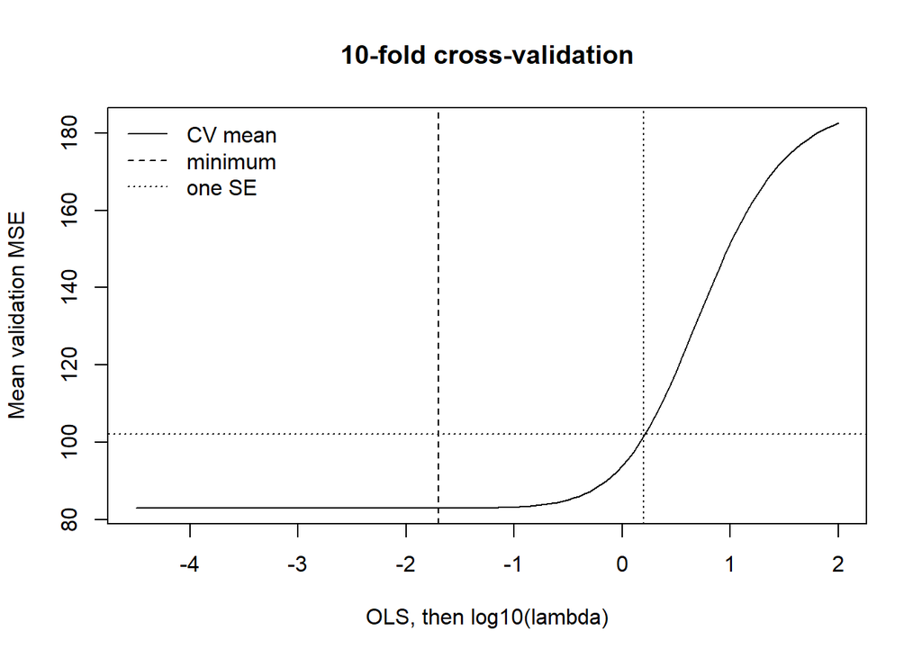

```r
fold_levels <- sort(unique(fold_id))
fold_mse <- matrix(
  NA_real_,
  nrow = length(fold_levels),
  ncol = length(lambda_grid)
)

for (k in seq_along(fold_levels)) {
  in_validation <- fold_id == fold_levels[k]

  X_fold_train <- X_train_raw[!in_validation, , drop = FALSE]
  y_fold_train <- y_train[!in_validation]
  X_fold_valid <- X_train_raw[in_validation, , drop = FALSE]
  y_fold_valid <- y_train[in_validation]

  for (j in seq_along(lambda_grid)) {
    fold_fit <- fit_ridge(
      X_fold_train,
      y_fold_train,
      lambda_grid[j],
      X_fold_valid
    )
    fold_mse[k, j] <- mean(
      (y_fold_valid - fold_fit$new_fitted)^2
    )
  }
}

cv_mean <- colMeans(fold_mse)
cv_se <- apply(fold_mse, 2, sd) / sqrt(10)

min_index <- which.min(cv_mean)
lambda_min <- lambda_grid[min_index]
one_se_limit <- cv_mean[min_index] + cv_se[min_index]
lambda_1se <- max(lambda_grid[cv_mean <= one_se_limit])

plot_x <- c(-4.5, log10(lambda_grid[-1]))
plot(
  plot_x,
  cv_mean,
  type = "l",
  xlab = "OLS, then log10(lambda)",
  ylab = "Mean validation MSE",
  main = "10-fold cross-validation"
)
abline(v = if (lambda_min == 0) -4.5 else log10(lambda_min), lty = 2)
abline(v = if (lambda_1se == 0) -4.5 else log10(lambda_1se), lty = 3)
abline(h = one_se_limit, lty = 3)
legend(
  "topleft",
  c("CV mean", "minimum", "one SE"),
  lty = c(1, 2, 3),
  bty = "n"
)
```

```r
data.frame(
  choice = c("CV minimum", "One SE"),
  lambda = c(lambda_min, lambda_1se),
  mean_CV_MSE = c(cv_mean[min_index], cv_mean[lambda_grid == lambda_1se])
)
```

```
      choice     lambda mean_CV_MSE
1 CV minimum 0.01995262    82.97765
2     One SE 1.58489319   101.59553
```

The minimum-error rule chooses lambda 0.01995. The one-standard-error cutoff is 102.208, so the largest eligible penalty is 1.58489. This rule accepts some increase in estimated error in exchange for a much more strongly shrunk model.

The scaling was repeated inside every fold. If I had scaled once using all 332 training rows, each validation fold would have influenced the means and scales used to fit its model.

### b. GCV

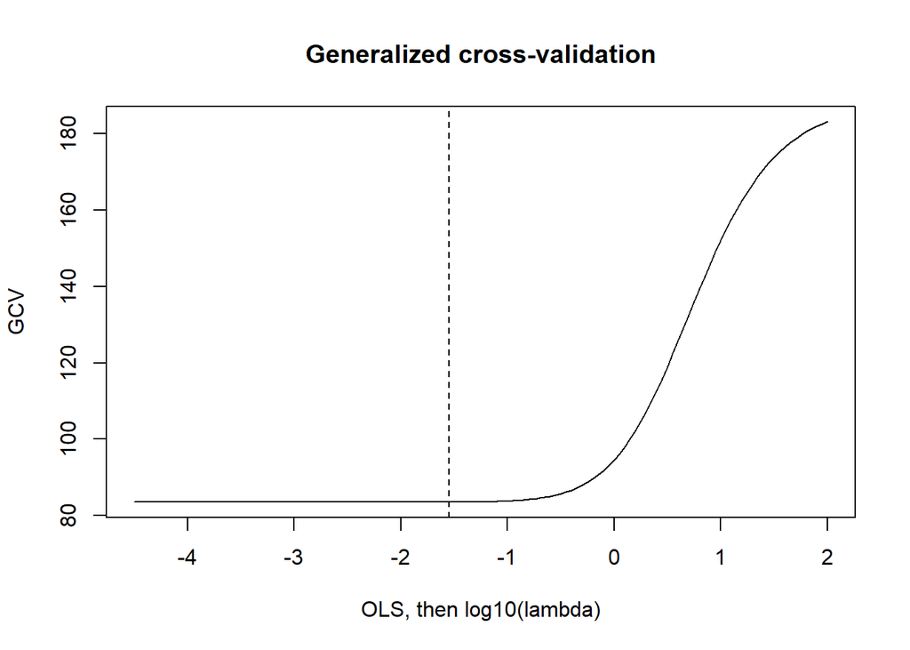

```r
full_train_fits <- lapply(
  lambda_grid,
  function(lambda) fit_ridge(X_train_raw, y_train, lambda)
)

training_mse_path <- vapply(
  full_train_fits,
  function(fit) mean((y_train - fit$fitted)^2),
  numeric(1)
)
df_path <- vapply(full_train_fits, function(fit) fit$df_eff, numeric(1))

gcv <- training_mse_path / (1 - df_path / nrow(X_train_raw))^2
lambda_gcv <- lambda_grid[which.min(gcv)]

plot(
  plot_x,
  gcv,
  type = "l",
  xlab = "OLS, then log10(lambda)",
  ylab = "GCV",
  main = "Generalized cross-validation"
)
abline(v = if (lambda_gcv == 0) -4.5 else log10(lambda_gcv), lty = 2)
```

```r
data.frame(
  lambda_GCV = lambda_gcv,
  minimum_GCV = min(gcv)
)
```

```
  lambda_GCV minimum_GCV
1 0.02818383    83.50191
```

GCV chooses lambda 0.02818. It uses one fit on the full training data and corrects the training MSE using effective degrees of freedom. Ten-fold CV instead makes ten separate validation comparisons and re-estimates preprocessing each time, so the two choices do not need to be identical.

### c. Final comparison

The three tuning choices above were fixed before the next chunk uses any test response values.

```r
y_test <- course_data$price[test_rows]

final_models <- data.frame(
  rule = c("OLS", "CV minimum", "One SE", "GCV"),
  lambda = c(0, lambda_min, lambda_1se, lambda_gcv)
)

final_models$effective_df <- NA_real_
final_models$training_MSE <- NA_real_
final_models$test_MSE <- NA_real_

for (j in seq_len(nrow(final_models))) {
  final_fit <- fit_ridge(
    X_train_raw,
    y_train,
    final_models$lambda[j],
    X_test_raw
  )

  final_models$effective_df[j] <- final_fit$df_eff
  final_models$training_MSE[j] <- mean(
    (y_train - final_fit$fitted)^2
  )
  final_models$test_MSE[j] <- mean(
    (y_test - final_fit$new_fitted)^2
  )
}

knitr::kable(
  final_models,
  digits = c(0, 5, 3, 3, 3),
  caption = "Training and final test results"
)
```

Training and final test results

| rule | lambda | effective_df | training_MSE | test_MSE |
| --- | --- | --- | --- | --- |
| OLS | 0.00000 | 7.000 | 80.094 | 66.322 |
| CV minimum | 0.01995 | 6.773 | 80.135 | 66.000 |
| One SE | 1.58489 | 3.033 | 100.374 | 81.200 |
| GCV | 0.02818 | 6.689 | 80.171 | 65.903 |

OLS has the lowest training MSE because it directly minimizes training squared error. The CV-minimum and GCV penalties are both mild, so their effective degrees of freedom and test MSE values stay close to OLS. The one-SE rule chooses much more shrinkage, reduces effective degrees of freedom substantially, and has a larger test MSE on this particular split.

The lowest number in the test-MSE column is only one observed result. I cannot look at that column and switch to its winner, because then the final test set would become another tuning set. That would make the reported minimum too optimistic. The correct comparison keeps the rules chosen from training information and treats the test table as their final assessment.

## explain-to-me skill

```markdown
---
name: explain-to-me
description: Explain what a STAT 432 homework question requires when the student explicitly invokes this skill. Do not solve the question.
---

# Intent

Help me understand a homework question while leaving the mathematical and computational work for me.

# Instructions

- Read the complete question before responding.
- Explain the main goal, required work, and expected output in straightforward language. Preserve the notation from the question.
- For Questions 2 and 3, consult [Ridge Regression: Stability Through Shrinkage](https://teazrq.github.io/stat432rpy/topics/ridge-regression/ridge-regression.html). For Questions 4 and 5, consult [From a Penalized Objective to a Fitted Ridge Model](https://teazrq.github.io/stat432rpy/topics/ridge-regression/optimization-and-cross-validation.html). Name one relevant section and briefly say why it helps.
- Suggest one reasonable first step, then ask what part is still unclear.
- Do not perform calculations or derivations, write solution code, or provide the final answer.
```